# Appendix B — Summary statistics

Table B.1: Summary Statistics

Pct. Missing

Min

Mean

Max

Histogram

population_m

0

0.5

1.8

39.5

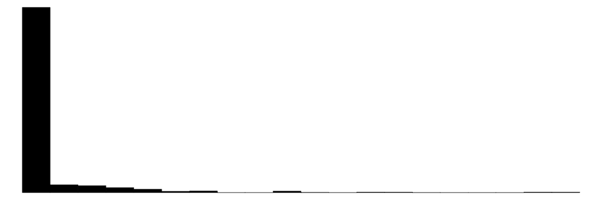

percent_workers_nonprofit

0

0.0

0.1

0.2

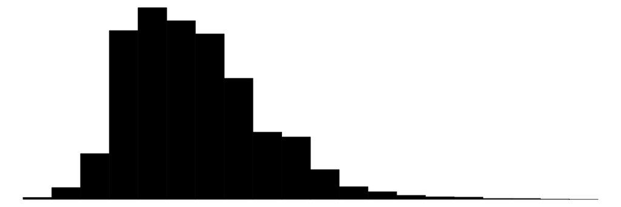

percent_workers_self_employed

0

0.0

0.0

0.1

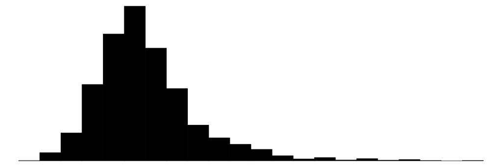

percent_workers_private_sector

0

0.5

0.7

0.8

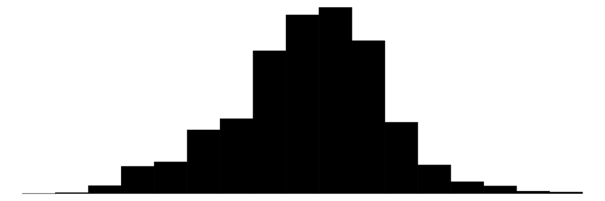

percent_workers_government

0

0.1

0.1

0.3

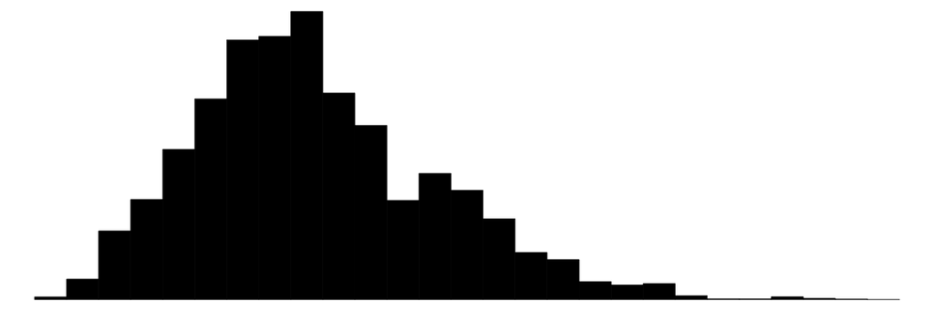

percent_education_bachelor_or_higher

0

0.1

0.3

0.8

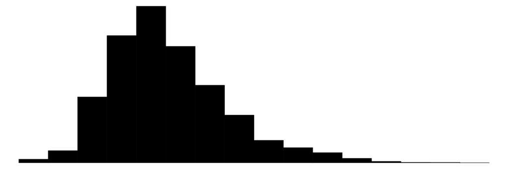

percent_public_assistance_or_snap_households

0

0.0

0.0

0.2

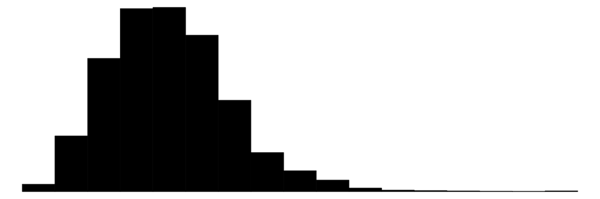

1 if senator ever served in state legislature

1

0.0

0.5

1.0

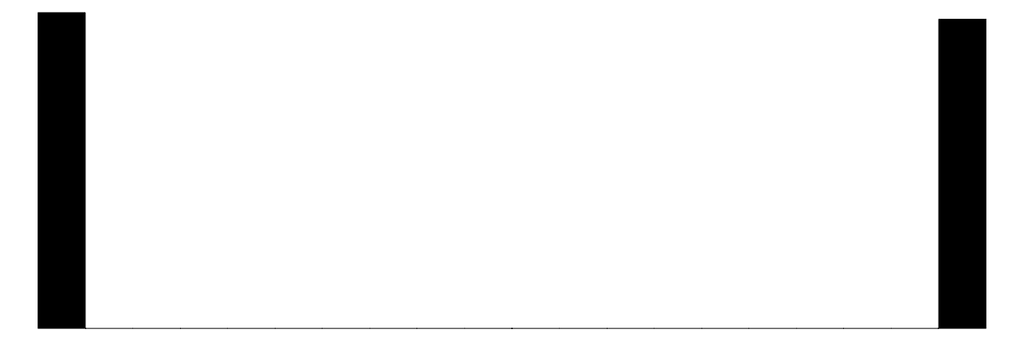

new_member

0

0.0

0.1

1.0

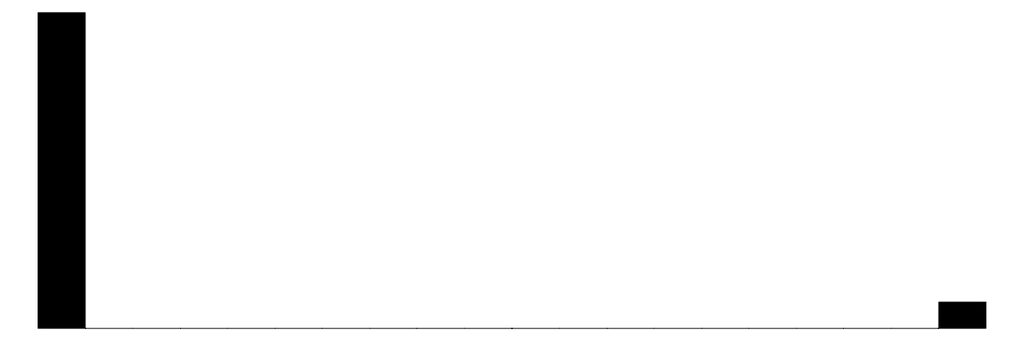

first_two

0

0.0

0.2

1.0

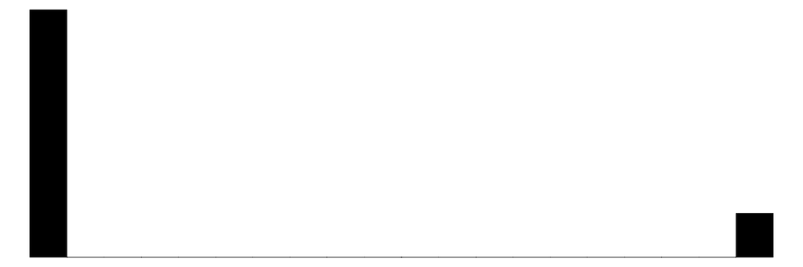

chair

0

0.0

0.1

1.0

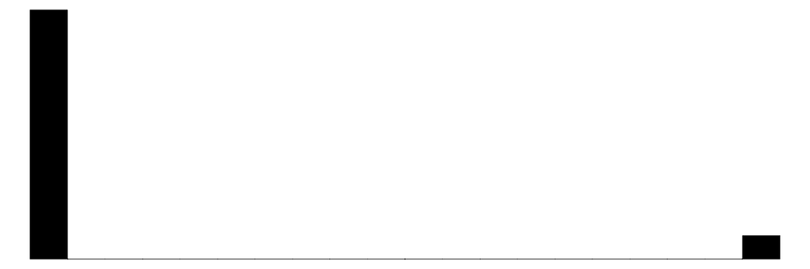

ranking_minority

0

0.0

0.1

1.0

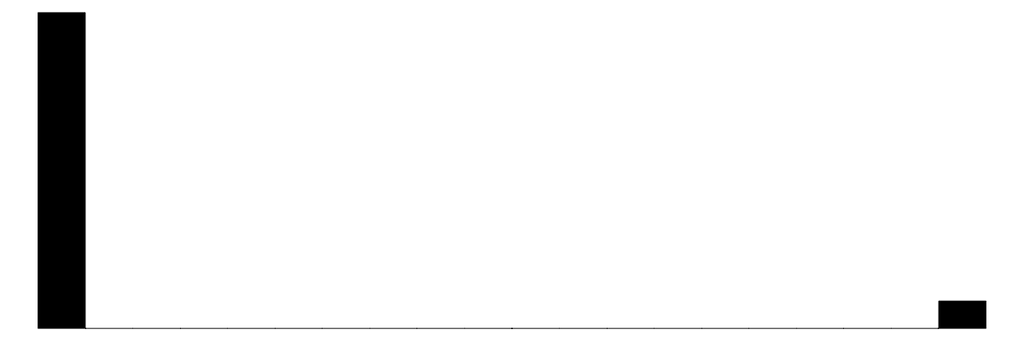

subchr

0

0.0

0.3

1.0

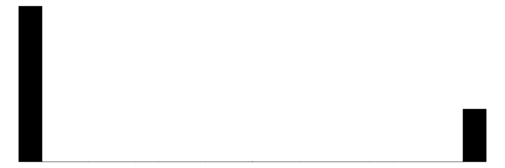

same_party

62

0.0

0.6

1.0

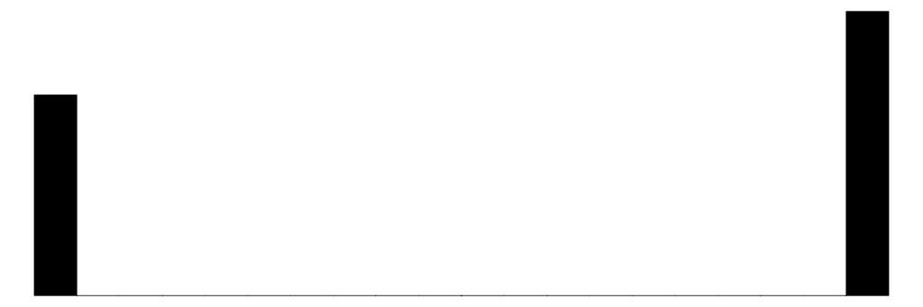

oversight

1

0.0

0.2

1.0

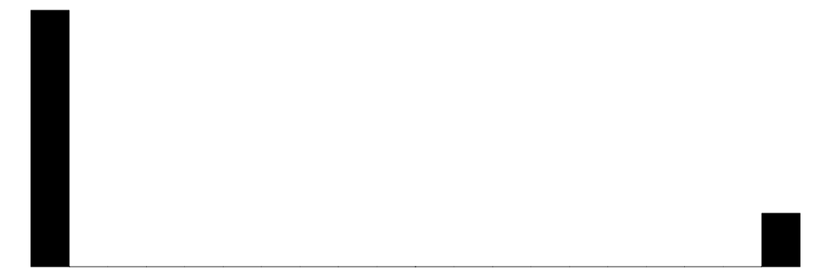

competitive

1

0.0

0.3

1.0

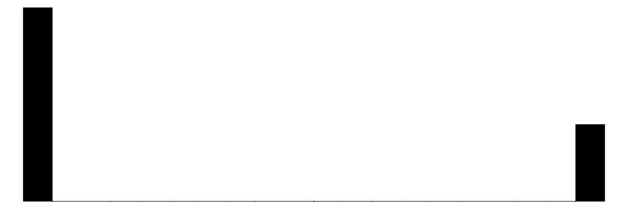

Competitive (57.5% Receipts), At Previous Year End

23

0.0

0.1

1.0

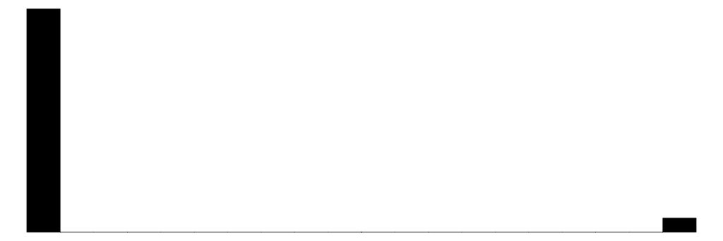

est_total_spending

50

0.0

1.0

2.2

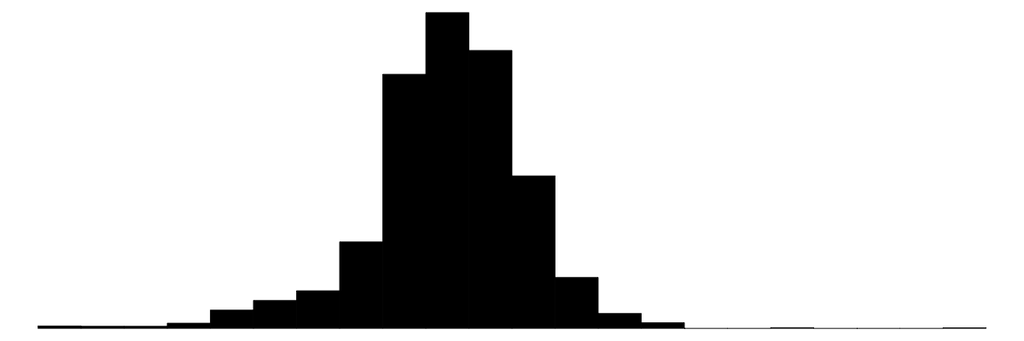

est_staff_spending

50

0.0

1.0

2.2

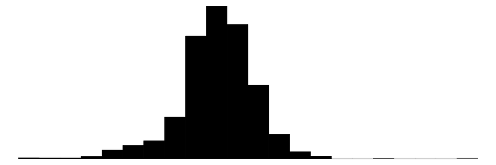

est_legis_spending

50

0.0

0.3

1.1

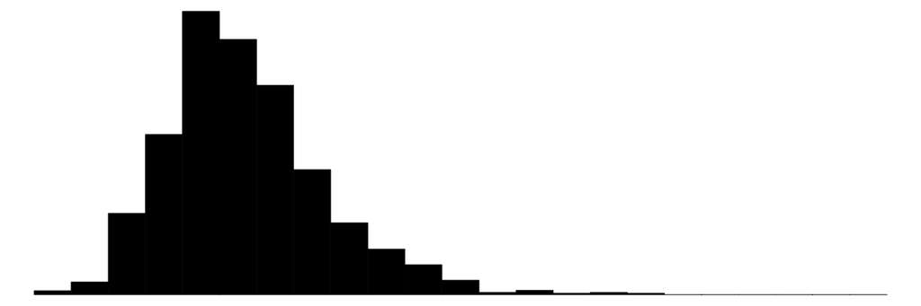

est_pol_spending

50

0.0

0.2

0.8

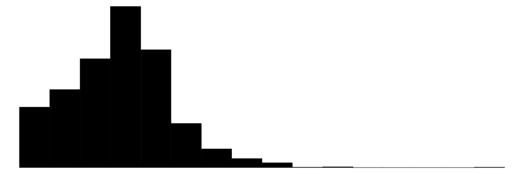

est_comm_spending

50

0.0

0.1

0.2

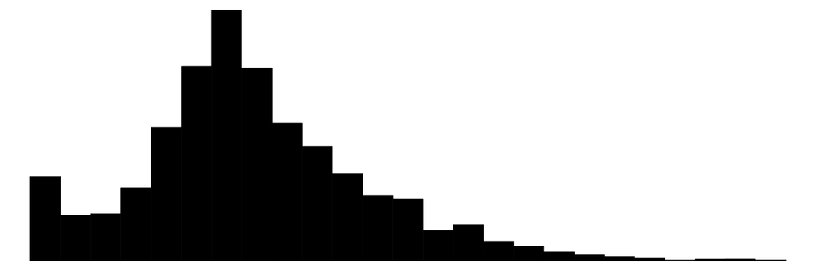

est_constit_spending

50

0.0

0.4

0.9

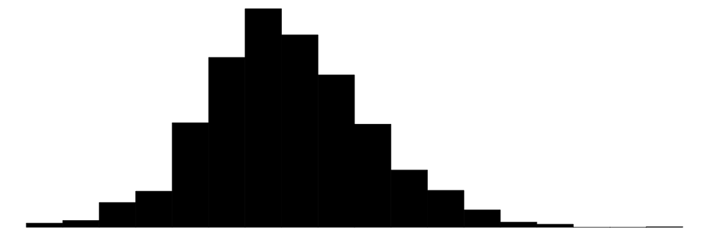

majority

0

0.0

0.6

1.0

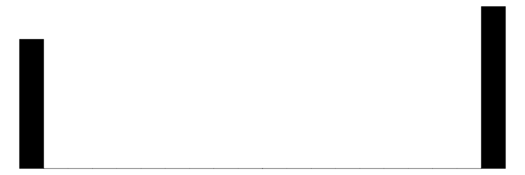

presidents_party

0

0.0

0.5

1.0

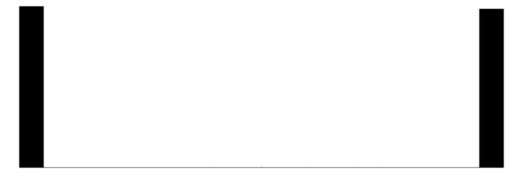

agency_ideo

0

-1.5

-0.2

1.9

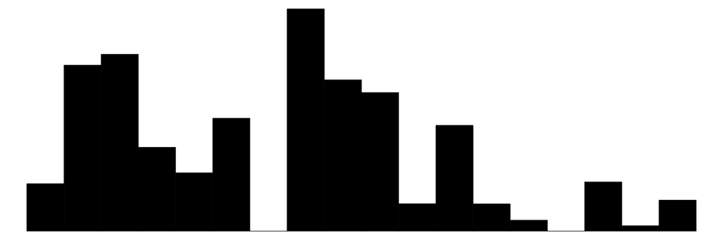

distance

0

0.0

0.8

2.7

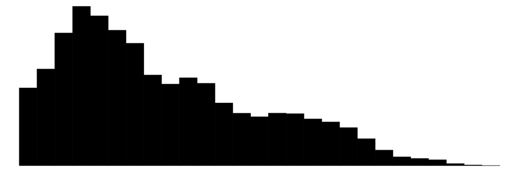

nominate_dim1

0

-0.8

0.1

0.9

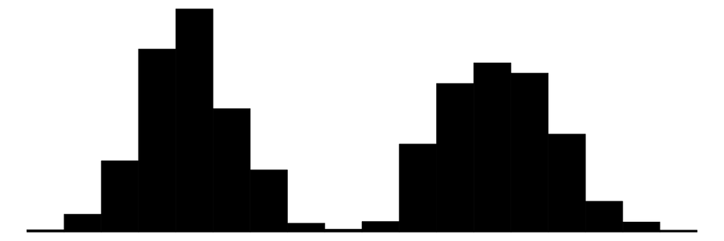

PACamount_m

1

0.0

1.1

55.3

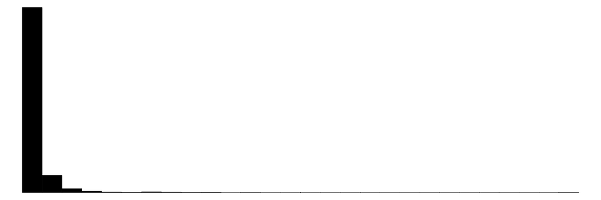

LES Classic, not including incorporation in other legislative vehicles

1

0.0

1.0

18.7

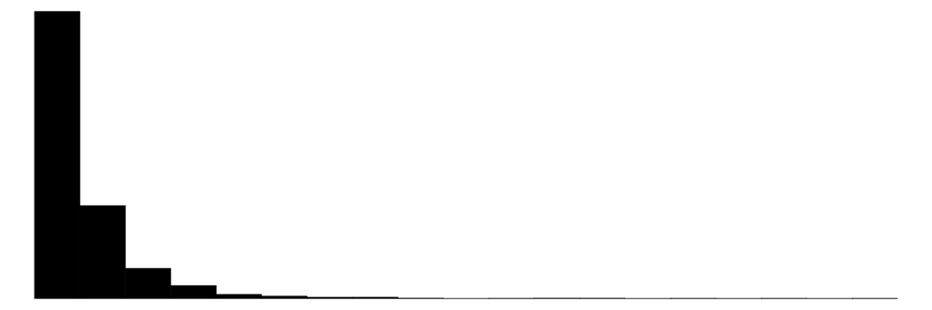

party

N

%

(D)

207451

48.8

(I)

1244

0.3

(R)

216215

50.9

## B.1 Correlations

### Legislative Effectiveness Scores

The Pearson’s product-moment correlation between annual Legislative Effectiveness Scores and total annual requests to federal agencies is 0.024 (p < .01). While we cannot necessarily infer from this correlation that more effective legislators are also consistently more effective at interbranch representation, Figure B.1 does show that legislators with the lowest Legislative Effectiveness Scores also do the least interbranch representation. Some of this relationship, however, may be driven by congressional leaders, particularly the Speaker, exercising power and effectiveness through other channels that are not captured in these measures.

Figure B.1: Correlation Between Legislative Effectiveness Scores and Interbranch Representation

[figure not shown]

The correlation between Legislative Effectiveness Scores and interbranch representation is, unsurprisingly, strongest for policy work. It is driven by the top and, especially, bottom deciles of both distributions.

Figure B.2: Correlation With Legislative Effectiveness Scores by Type of Interbranch Representation

(a) Overall

[figure not shown]

(b) Indiv. Constituents

[figure not shown]

(c) Corporate Constituents

[figure not shown]

(d) Nonprofits and Local Governments

[figure not shown]

(e) Policy Work

[figure not shown]

(f) Policy Work on Behalf of Business

[figure not shown]

### Fundraising

As shown in Figure B.3, the correlation between corporate PAC fundraising and interbranch representation is driven even more by the top and, especially, bottom deciles of both.

Figure B.3: Correlation Between Corporate Political Action Committee Donations and Interbranch Representation

[figure not shown]

The correlation between annual corporate PAC contributions and total annual requests to federal agencies is 0.08 (p< .001), a slightly stronger correlation than that between LES and requests to federal agencies. The fact that some legislators do both more fundraising and more interbranch representation, also supported by our other findings throughout this book, presents a significant challenge to our understanding of how fundraising work fits in with legislators’ other activities. Critics of Congress – sometimes including members of Congress themselves – decry fundraising as, at best, a vacuous distraction from Congress’s real work. It is assumed that, by engaging in more fundraising activities, members of Congress are sacrificing legislative and representational work. From our analysis, however, that appears not necessarily to be the case.

Figure B.4: Correlation With Corporate Political Action Committee Donations by Type of Interbranch Representation

(a) Overall

[figure not shown]

(b) Indiv. Constituents

[figure not shown]

(c) Corporate Constituents

[figure not shown]

(d) Nonprofits and Local Governments

[figure not shown]

(e) Policy Work

[figure not shown]

(f) Policy Work on Behalf of Business

[figure not shown]

While more research is needed to understand the precise nature of the relationship between interbranch representation and these other measures of what legislators do, the correlations presented here suggest that at least some legislators, rather than choosing to concentrate their efforts only on one type of activity, simply excel at everything.

### Correlations among variables used in the analyses

Figure B.5 shows cross tabulations among all variables used in the analyses and by decile of total interbranch representation. Many of the patterns we document with regression analysis are clear in these unconditional correlations as well. For example, district population is correlated with total interbranch representation, with the top two deciles doing more and the bottom seven deciles doing less. Likewise, being in the Senate is associated with being in the top 30% of legislators. Weaker associations for district demographics, various forms of institutional capacity and experience, and competitive elections are also apparent. Those with more extreme nominate scores, Republicans, and legislators in the majority are less likely to be in the top decile, overall.

Figure B.5: Cross Correlations - Total Interbranch Representation

[figure not shown]

Figure B.6 shows many of the same patterns in cross tabulations for deciles of individual interbranch representation. Notably, we see that the positive association between Republicans and individual interbranch representation is driven by deciles 5-8, not the top decile of congressional offices.

Figure B.6: Correlations by Decile of Individual Constituent Interbranch Representation

[figure not shown]

Figure B.7 shows cross tabulations shows many of the same patterns for interbranch representation on behalf of businesses. The correlation with percent of district with a college degree is lower, and there is no longer a correlation with being in the minority. There is now a positive association with being a Republican and being in all five deciles at the top of the distribution.

Figure B.7: Correlations by Decile of Corporate Constituent Interbranch Representation

[figure not shown]

Figure B.8 shows many of the same patterns related to capacity in the raw cross tabulations for interbranch representation on behalf of nonprofits and local governments. The main differences are (1) a strong negative correlation between being a Republican officeholder and this type of interbranch representation and (2) a strong positive relationship with being in the president’s party (aligned with Berry et al. 2010).

Figure B.8: Correlations by Decile of Nonprofit and Local Government Interbranch Representation

[figure not shown]

Figure B.9 shows many of the same patterns again related to capacity and district demand. Unsurprisingly, the correlation with LES scores is stronger, and there is now somewhat of a relationship for subcommittee chairs that is largely absent from non-policy work forms of interbranch representation. There is again a positive relationship between policy work and being in the president’s party and a negative relationship with being a Republican.

Figure B.9: Correlations by Decile of Policy Work

[figure not shown]

Figure B.10, showing policy work on behalf of particular industries, shows many of the same patterns as general policy work seen in Figure B.9, but stronger correlations with corporate PAC fundraising and weaker relationships with committee chair positions and legislative effectiveness scores. Interestingly, republican offices are less likely to be in the top decile for corporate policy work. Members with the top 20% of large positive or negative NOMINATE scores are also much less likely to do policy work on behalf of businesses, but this is partially driven by republicans having, on average, NOMINATE scores more distant from zero.

Figure B.10: Correlations by Decile of Corporate Policy Work

[figure not shown]

## B.2 Staff data from Crosson et al. (2021)

Figure B.11 shows that staff allocations vary across legislators and within legislators over time. These data are from Crosson et al. (2021). Each dot is a legislator-congress observation of the estimated money the office spent on each type of staff. Lines link legislative offices across congresses.

Figure B.11: Staff Data Coverage

[figure not shown]

Figure B.12: Correlations With Staff of Individual Constituent Interbranch Representation

[figure not shown]

Figure B.13: Correlations With Staff of Corporate Constituent Interbranch Representation

[figure not shown]

Figure B.14: Correlations With Staff of Nonprofit and Local Government Interbranch Representation

[figure not shown]

Figure B.15: Correlations With Staff of Policy Work

[figure not shown]

Figure B.16: Correlations With Staff of Corporate Policy Work

[figure not shown]

Berry, Christopher, Barry Burden, and William Howell. 2010. “The President and the Distribution of Federal Spending.” *American Political Science Review* 104 (4): 783–99.

Crosson, Jesse M., Alexander C. Furnas, Timothy LaPira, and Casey Burgat. 2021. “Partisan Competition and the Decline in Legislative Capacity Among Congressional Offices.” *Legislative Studies Quarterly* 46 (3): 745–89.